# Presenting Your Poster

## Forms of scientific communication

- **Peer-reviewed journal article**
  - Gold standard
  - Has been carefully reviewed by other scientists
- **Oral presentation at a conference**
  - May contain published and/or unpublished results
  - Presented to an expert audience w/ questions
- **Poster presentation at a conference**
  - Informal presentation
  - Visually appealing
  - Usually contains unpublished results
- **Modern sci-comm is changing!**
  - blogs, podcasts, tweets, etc

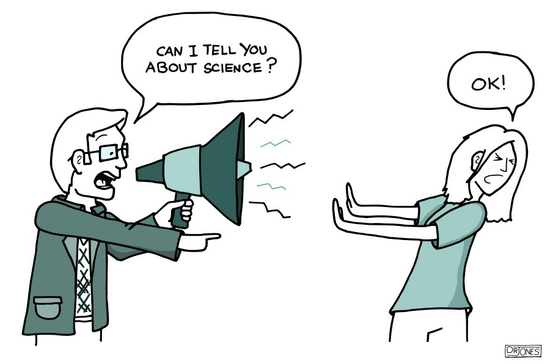

## First impressions and the “elevator pitch”

- **Your first impression on the audience is critical to guarantee their interest**
- **Begin your presentation with a very short synopsis with three vital bits of information:**
  - What is your research topic?
  - What have you found?
  - Why is it important?
- **Focus on the big picture (top of the funnel)—you want to hook them with the big picture so they are then excited to hear about the small details.**
  - 3 minute thesis will help!

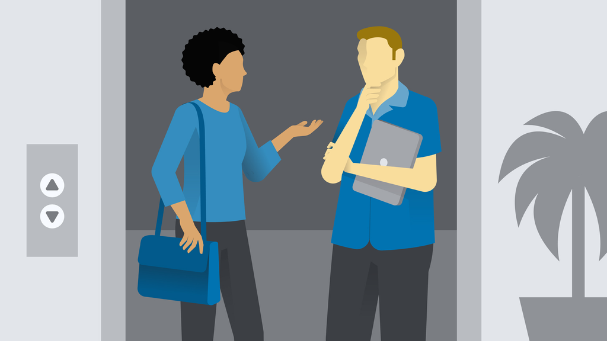

## Telling your story

- **After your elevator pitch, build the narrative of your research in around 5 min**
  - Like any story, it needs a beginning, middle, and end
- **Beginning: set the scene and introduce the main characters**
  - Provide the necessary background information for your audience
  - How did this lead to your research question?
  - What were you hoping to find out and why?
  - Who are the main characters? (e.g. drug, disease, gene, cell type, technique, etc.)

[figure not shown]

## Telling your story

- **Middle: the adventure…**
  - How did you get from your research question to your conclusion?
  - Why did you choose to take that route?
  - What did you find on your way?
  - Were there any interesting twists?
- **End: the conclusion to the story.**
  - What is the ultimate consequence of your journey?
  - What does this mean for your main characters?

[figure not shown]

## Pro Tips: Nailing your poster presentation

- **Be confident — you are the expert on this subject**
  - Try to be yourself and let your personality show through
- **Try not to talk too rapidly**
  - avoid too much jargon
- **Make eye contact with your audience**
- **Use poster images to help you explain things—a picture is worth a thousand words**
- **It is a good idea to check your audience’s understanding**
  - “Have I been clear enough…?”
  - “Should I go into more detail…?”

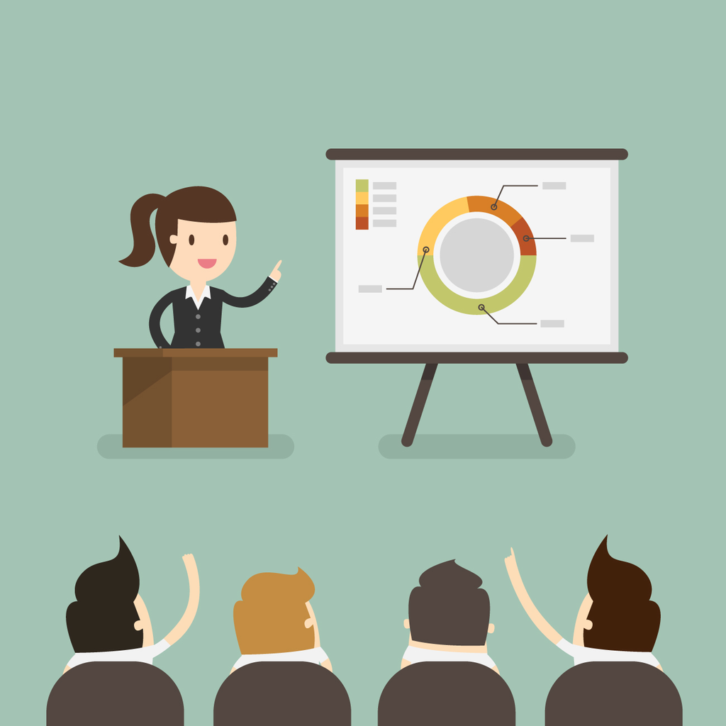

## Consider your audience and objectives

- **Presenting a poster is a performance, and just like any performance, practice is a major factor in success**
- **Rehearse what you will say ahead of time OUT LOUD**
  - write down notes with the main points. You can refer to them as you develop your presentation (not while speaking).
  - Force yourself to speak aloud even if it seems silly
  - After you feel more confident, try giving it to friends and family

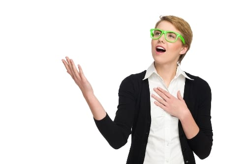

## Before your presentation…

- **Understand completely why everything is included on the poster and its implications for your project or topic**
- **Memorize your “elevator pitch”**
- **Know your key points without referring to written notes**
- **Be ready to answer likely questions with confidence**
  - think about what questions ahead of time
- **Know how to deal with difficult questions that you might not be able to answer fully**
  - expect someone will ask that ? you can’t answer
  - it is ‘OK’ to say you do not know

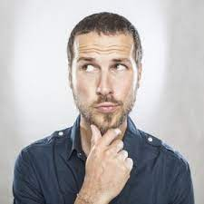

## 3 Minute Thesis: Your elevator pitch

- **International competition to explain your research in a language appropriate to a non-specialist office**
  - Someone else’s grandma in the elevator
- **Goal is to increase your capacity to effectively communicate science**
  - used at >900 universities across 85 countries
- **Recent winners:**
  - https://threeminutethesis.uq.edu.au/watch-3mt

[figure not shown]

## 3 Minute Thesis: The Rules

- **A single static PowerPoint slide is permitted**
- **No slide transitions, animations or ‘movement’ of any description are allowed.**
  - no additional electronic media or props
- **Presentations are limited to 3 minutes maximum**
  - competitors exceeding 3 minutes are disqualified.
- **Presentations are to be spoken word (e.g. no poems, raps or songs)**
- **Dr. C will provide prizes!!!**
  - grade based mostly on participation